# Visualizing metagenes with MetaPlotR

### Understanding the data

This is the final script in the MetaPlotR pipeline. The input for this file is the metagene coordinates file outputted from rel_and_abs_dist_calc.pl

Read in file

```r
setwd (dir = '~/Projects/metagene_Bioinformatics/')
dist <- read.delim ("dist.measures.txt", header = T)
```

View the number of rows and columns in the dataset

```r
dim(dist)
```

```
## [1] 20903    14
```

View the first few lines

```r
head(dist)
```

```
##    chr  coord gene_name          refseqID rel_location utr5_st utr5_end
## 1 chr1 878151    SAMD11 ENST00000342066.3     1.624145    1359     1277
## 2 chr1 879955     NOC2L ENST00000327044.6     2.242857    2418     2369
## 3 chr1 934375      HES4 ENST00000304952.6     2.673684     867      730
## 4 chr1 934375      HES4 ENST00000428771.2     2.659794    1006      808
## 5 chr1 934375      HES4 ENST00000484667.2     2.719101     641      634
## 6 chr1 934423      HES4 ENST00000304952.6     2.168421     819      682
##   cds_st cds_end utr3_st utr3_end utr5_size cds_size utr3_size
## 1   1276    -769    -770    -1191        82     2045       421
## 2   2368     119     118     -371        49     2249       489
## 3    729      64      63      -31       137      665        94
## 4    807      64      63      -33       198      743        96
## 5    633      64      63      -25         7      569        88
## 6    681      16      15      -79       137      665        94
```

The input file contains 20903 rows and 14 columns. Each row represents a single site (in this example an m6A site). The column headers for the first four columns are self explanatory. The fifth column “rel_location” (for relative location) contains the calculated metagene coordinates. In its simplest form (i.e. non-normalized), the metagene coordinates from 0 to 1 represent the 5’UTR with 0 being closer to the beginnig of the 5’UTR and 1 closer to the end. Similarly, 1 to 2 represents the CDS and 2 to 3 the 3’UTR. A histogram/density plot of the “rel_location” value gives the standard metagene.

The last three columns contain the lengths of the 5’UTRs, coding sequences and 3’UTRs.

### Selecting gene isoforms for metagene analysis

The dataset is redundant – a given site is represented by multiple transcript isoforms. The choice of which isoforms to choose should be informed by the underlying biology. For example, if a gene expression dataset is available, one option may be to pick the highest expressed isoform. Another option is to pick the longest isoform, which is likely to capture more sites. Below is sample code for picking the largest isoforms

```r
trx_len <- dist$utr5_size + dist$cds_size + dist$utr3_size
dist <- dist[order(dist$gene_name, trx_len),] # sort by gene name, then transcript length
dist <- dist[duplicated(dist$gene_name),] # select the longest transcript
dim(dist)
```

```
## [1] 16721    14
```

### Visualizing the metagene

#### A simple histogram

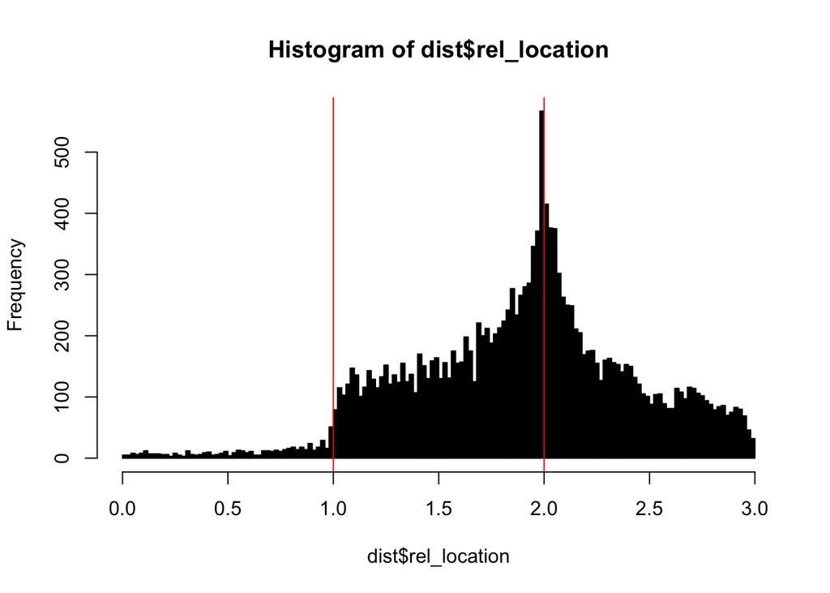

```r
hist(dist$rel_location, breaks = 200, col = "black")
abline (v = 1, lty  = 1, col = "red")
abline (v = 2, lty  = 1, col = "red")
```

In this plot, the range 0 to 1 represents the 5’UTR, 1 to 2 the CDS, and 2 to 3 the 3’UTR (as delineated by the red vertical lines). From this figure, one may conclude that the events (in this case m6A sites) occur througout the gene body with a peak around the stop codon and a precipitous transition from the 5’UTR to the CDS. However, one caveat is that the three regions of interest are drawn with equal widths. On average, this is not the case. We can view the average lenghts in this dataset:

```r
summary(data.frame(dist$utr5_size, dist$cds_size, dist$utr3_size))
```

```
##  dist.utr5_size    dist.cds_size   dist.utr3_size
##  Min.   :    0.0   Min.   :   38   Min.   :    0
##  1st Qu.:  103.0   1st Qu.:  824   1st Qu.:  332
##  Median :  206.0   Median : 1442   Median :  768
##  Mean   :  289.8   Mean   : 1924   Mean   : 1205
##  3rd Qu.:  362.0   3rd Qu.: 2402   3rd Qu.: 1586
##  Max.   :14959.0   Max.   :26393   Max.   :17320
```

The median lengths are 206, 1442, and 768 for the 5’UTR, CDS and 3’UTR, respectively.

To account for these length differences in the metagene, we can re-scale the widths of the 5’UTR and 3’UTR relative to the CDS (which is set constant to a width of 1 unit). So first we calculate a simple scale factor (SF):

```r
utr5.SF <- median(dist$utr5_size, na.rm = T)/median(dist$cds_size, na.rm = T)
utr3.SF <- median(dist$utr3_size, na.rm = T)/median(dist$cds_size, na.rm = T)
```

The SF for the 5’UTR is 0.14 and for the 3’UTR is 0.53. The followign code rescales these regions accordingly:

```r
# assign the regions to new dataframes
utr5.dist <- dist[dist$rel_location <= 1, ]
cds.dist <- dist [dist$rel_location <= 2 & dist$rel_location > 1, ]
utr3.dist <- dist[dist$rel_location > 2, ]

# rescale 5'UTR and 3'UTR
library("scales")
utr5.dist$rel_location <- rescale(utr5.dist$rel_location, to = c(1-utr5.SF, 1), from = c(0,1))
utr3.dist$rel_location <- rescale(utr3.dist$rel_location, to = c(2, 2+utr3.SF), from = c(2,3))
```

Finally, plot the metagene with the rescaled UTRs

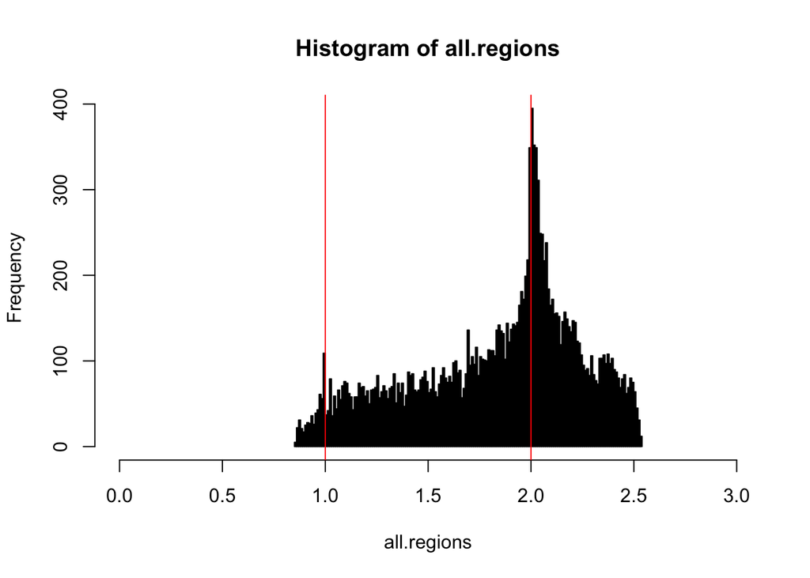

```r
# Combine and plot
## Histogram
all.regions <- c(utr5.dist$rel_location, cds.dist$rel_location, utr3.dist$rel_location)
hist.data <- hist(all.regions, breaks = 200, col = "black", xlim = c(0,3)) # plot and save to variable
abline (v = 1, lty  = 1, col = "red")
abline (v = 2, lty  = 1, col = "red")
```

### Alternate representations of the metagene

#### A line plot

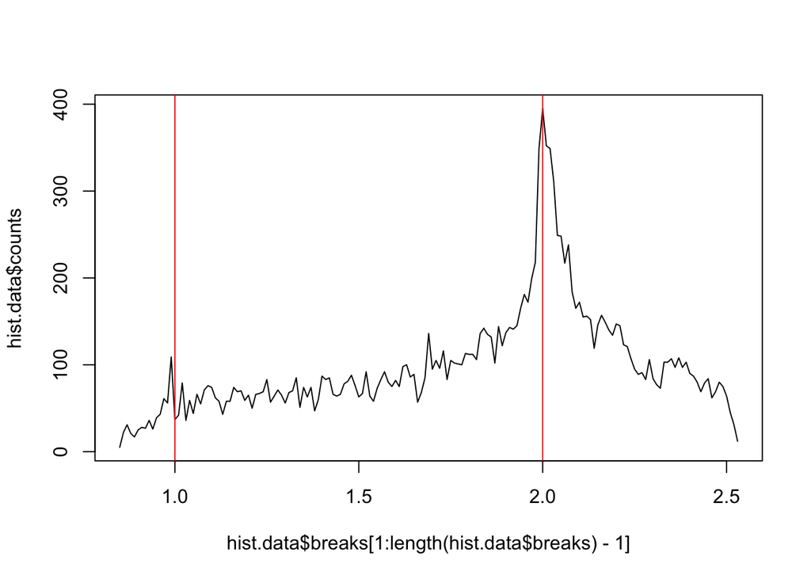

```r
plot(hist.data$breaks[1:length(hist.data$breaks)-1], hist.data$counts, type = 'l')
abline (v = 1, lty  = 1, col = "red")
abline (v = 2, lty  = 1, col = "red")
```

A smooth density plot

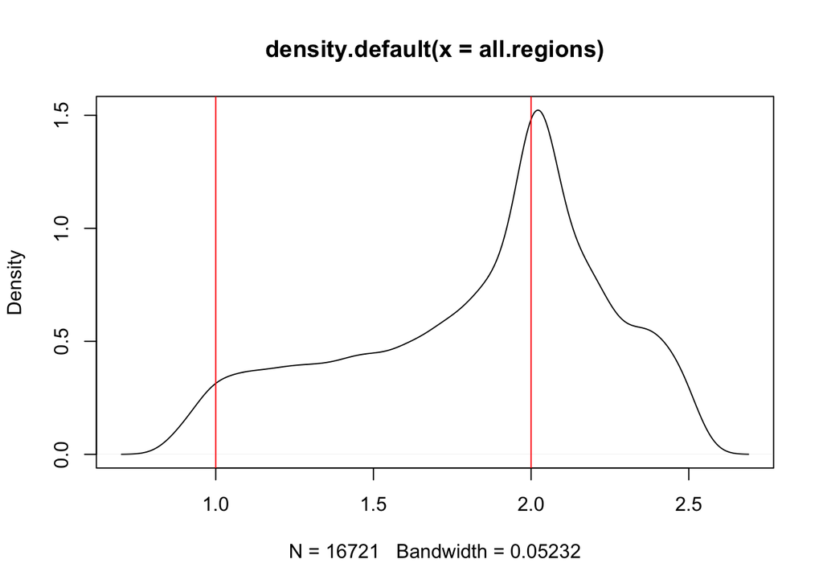

```r
plot(density(all.regions))
abline (v = 1, lty  = 1, col = "red")
abline (v = 2, lty  = 1, col = "red")
```

### Mapping the absolute distance of sites from fixed features

```r
head(dist[,6:11])
```

```
##       utr5_st utr5_end cds_st cds_end utr3_st utr3_end
## 4713     1057      927    926    -615    -616     -645
## 4712     1191     1026   1025    -615    -616     -648
## 13159     448      356    355    -841    -842    -1017
## 13154     190      104    103   -1051   -1052    -2239
## 13157     442      356    355    -799    -800    -1987
## 13160    2270     2184   2183    1029    1028     -159
```

For example, we can view the distribution of sites within 100 nucleotides of the stop codon